# ess_data_wrangling

GC & JL

2022-11-21

## ESS

| Formato | Extension | Descripcion |
| --- | --- | --- |
| Plano | csv | Archivo de datos separados por comas |
| SPSS | sav | Variables y etiquetas |
| Excel | xlsx | Etiquetas |
| RData | Rdata | Objetos de R |

```r
if (!require("pacman")) install.packages("pacman")
pacman::p_load(tidyverse, haven)

library(haven)
ESS10 <- read_dta("data/ESS10.dta/ESS10.dta") #formato de STATA
```

Escogemos una selección de variables en función de la pregunta que queremos contestar

```r
df <- ESS10 %>%
  dplyr::select(country = cntry, gender = gndr, health, happy, id= idno,news=nwspol, internet=netusoft,polintr,cptppola,trstplt,trstprt, trstsci,
                 vote, trstprl,lrscale,stfdem,stfhlth,stfedu,freehms,
                 hmsacld,atcherp,agea, education=edulvlb, unemployd = uempla,
                 partnr_educ=edulvlpb,)
```

Entendemos qué significan cada una de las variables? No, pues entonces acudid al “codebook” de la base de datos para entenderlo. Algunas tienen nombres bastante intuitivos, otras no tanto. A estas últimas podemos renombrarlas antes de seleccionarlas e incluirlas en nuestro dataframe particular.

A continuación, podemos utilizar otro paquete que nos da una impresión más precisa

```r
pacman::p_load(skimr)

df %>% skim
```

Data summary

| Name | Piped data |
| --- | --- |
| Number of rows | 18060 |
| Number of columns | 25 |
| _______________________ |  |
| Column type frequency: |  |
| character | 1 |
| numeric | 24 |
| ________________________ |  |
| Group variables | None |

**Variable type: character**

| skim_variable | n_missing | complete_rate | min | max | empty | n_unique | whitespace |
| --- | --- | --- | --- | --- | --- | --- | --- |
| country | 0 | 1 | 2 | 2 | 0 | 10 | 0 |

**Variable type: numeric**

| skim_variable | n_missing | complete_rate | mean | sd | p0 | p25 | p50 | p75 | p100 | hist |
| --- | --- | --- | --- | --- | --- | --- | --- | --- | --- | --- |
| gender | 0 | 1.00 | 1.55 | 0.50 | 1 | 1.00 | 2 | 2.00 | 2 | ▆▁▁▁▇ |
| health | 24 | 1.00 | 2.25 | 0.92 | 1 | 2.00 | 2 | 3.00 | 5 | ▅▇▆▂▁ |
| happy | 46 | 1.00 | 7.14 | 2.05 | 0 | 6.00 | 8 | 9.00 | 10 | ▁▁▅▇▅ |
| id | 0 | 1.00 | 18932.19 | 5173.81 | 10002 | 14493.25 | 18879 | 23416.75 | 27932 | ▇▇▇▇▇ |
| news | 435 | 0.98 | 78.56 | 112.85 | 0 | 30.00 | 60 | 90.00 | 1200 | ▇▁▁▁▁ |
| internet | 27 | 1.00 | 3.96 | 1.54 | 1 | 3.00 | 5 | 5.00 | 5 | ▂▁▁▁▇ |
| polintr | 42 | 1.00 | 2.78 | 0.88 | 1 | 2.00 | 3 | 3.00 | 4 | ▂▆▁▇▅ |
| cptppola | 485 | 0.97 | 1.86 | 0.97 | 1 | 1.00 | 2 | 2.00 | 5 | ▇▆▃▁▁ |
| trstplt | 211 | 0.99 | 3.45 | 2.53 | 0 | 1.00 | 3 | 5.00 | 10 | ▇▅▅▂▁ |
| trstprt | 266 | 0.99 | 3.38 | 2.48 | 0 | 1.00 | 3 | 5.00 | 10 | ▇▅▅▂▁ |
| trstsci | 6215 | 0.66 | 6.79 | 2.46 | 0 | 5.00 | 7 | 9.00 | 10 | ▂▂▅▇▆ |
| vote | 184 | 0.99 | 1.39 | 0.61 | 1 | 1.00 | 1 | 2.00 | 3 | ▇▁▃▁▁ |
| trstprl | 306 | 0.98 | 4.14 | 2.75 | 0 | 2.00 | 4 | 6.00 | 10 | ▇▆▇▅▁ |
| lrscale | 2308 | 0.87 | 5.39 | 2.39 | 0 | 4.00 | 5 | 7.00 | 10 | ▂▂▇▃▂ |
| stfdem | 462 | 0.97 | 4.91 | 2.68 | 0 | 3.00 | 5 | 7.00 | 10 | ▆▆▇▇▂ |
| stfhlth | 144 | 0.99 | 5.46 | 2.70 | 0 | 3.00 | 6 | 8.00 | 10 | ▅▅▇▇▃ |
| stfedu | 859 | 0.95 | 5.61 | 2.54 | 0 | 4.00 | 6 | 8.00 | 10 | ▃▅▇▇▃ |
| freehms | 492 | 0.97 | 2.42 | 1.21 | 1 | 1.00 | 2 | 3.00 | 5 | ▆▇▅▂▂ |
| hmsacld | 687 | 0.96 | 3.24 | 1.39 | 1 | 2.00 | 3 | 4.00 | 5 | ▅▆▆▇▇ |
| atcherp | 249 | 0.99 | 6.13 | 2.68 | 0 | 5.00 | 6 | 8.00 | 10 | ▃▃▇▇▅ |
| agea | 120 | 0.99 | 50.89 | 18.45 | 15 | 36.00 | 51 | 66.00 | 90 | ▅▇▇▇▃ |
| education | 65 | 1.00 | 413.03 | 251.63 | 0 | 313.00 | 323 | 610.00 | 5555 | ▇▁▁▁▁ |
| unemployd | 0 | 1.00 | 0.04 | 0.19 | 0 | 0.00 | 0 | 0.00 | 1 | ▇▁▁▁▁ |
| partnr_educ | 8117 | 0.55 | 421.85 | 227.42 | 0 | 321.00 | 323 | 610.00 | 5555 | ▇▁▁▁▁ |

```r
sapply(df, class)
```

```
## $country
## [1] "character"
##
## $gender
## [1] "haven_labelled" "vctrs_vctr"     "double"
##
## $health
## [1] "haven_labelled" "vctrs_vctr"     "double"
##
## $happy
## [1] "haven_labelled" "vctrs_vctr"     "double"
##
## $id
## [1] "numeric"
##
## $news
## [1] "haven_labelled" "vctrs_vctr"     "double"
##
## $internet
## [1] "haven_labelled" "vctrs_vctr"     "double"
##
## $polintr
## [1] "haven_labelled" "vctrs_vctr"     "double"
##
## $cptppola
## [1] "haven_labelled" "vctrs_vctr"     "double"
##
## $trstplt
## [1] "haven_labelled" "vctrs_vctr"     "double"
##
## $trstprt
## [1] "haven_labelled" "vctrs_vctr"     "double"
##
## $trstsci
## [1] "haven_labelled" "vctrs_vctr"     "double"
##
## $vote
## [1] "haven_labelled" "vctrs_vctr"     "double"
##
## $trstprl
```

[output cut: 19 more lines]

```
##
## $atcherp
## [1] "haven_labelled" "vctrs_vctr"     "double"
##
## $agea
## [1] "haven_labelled" "vctrs_vctr"     "double"
##
## $education
## [1] "haven_labelled" "vctrs_vctr"     "double"
##
## $unemployd
## [1] "haven_labelled" "vctrs_vctr"     "double"
##
## $partnr_educ
## [1] "haven_labelled" "vctrs_vctr"     "double"
```

```r
pacman::p_load(sjlabelled)

df <- df %>% mutate(country = as_label(country), gender = as_label(gender) )
```

Sin embargo no es la única opción disponible. También puedes realizar cualquier operación matemática. Vamos a probar a efectuar un escalamiento con la función `scale()` y un centrado de la variable `health`

```r
df <- df %>% mutate(happy_scaled = scale(happy),
                            health_centered = health - mean(health) )
```

Ahora observa el resultado de health_centered. Verás que son valores perdidos. Eso ocurre porque la función `mean()`no tolera los valores perdidos por defecto. Usa `?mean`para averiguar cual es la manera de que haga la media ignorando los valores perdidos.

```r
# solution
df <- df %>% mutate(happy_scaled = scale(happy),
                            health_centered = health - mean(health, na.rm=TRUE))
```

No te quedes aquí. Averigua todo lo que puedas de los usos de `mutate()` y de `select()`. Por ejemplo, prueba a cargar el paquete `MASS` y tratar de hacer un select. Verás que posiblemente te genere un error debido a que existe una función igual a `select()` en `MASS`. Será buena idea especificar el paquete del que quieres usar ’select()`, por ejemplo:`dplyr::select()`. Para poder seguir sin tener que especificar el paquete, podemos ejecutar esto`unloadNamespace(“MASS”)`para que`MASS` no sea un incordio.

Además, a la hora de seleccionar columnas, tienes muchas opciones. Como ejemplos:

```r
library(MASS)
# des-seleccionar usando el "-"
df_sin_happy <- df %>% dplyr::select(-happy)

# seleccionar usando funciones de ayuda como
# contains("contiene_esto_en_su_nombre")
# starts_with("empieza_por")
# https://dplyr.tidyverse.org/reference/select.html
# esta línea seleccionará todas las columnas que contengan en su nombre "net"... que en una búsqueda rápida parece una palabra que se repite
df_net <- df %>% dplyr::select(contains("net"))
df_trs <- df %>% dplyr:: select(starts_with("trs"))
# o por sus indices
df_1_3 <- df %>% dplyr:: select(1:3)

write.csv(df, "datos_ess.csv")
```

## Función `group_by`

Una vez que tenemos nuestro dataset correcto, es la hora de querer conocer cosas sobre los diferentes grupos presentes. En nuestro caso tenemos género y país. Queremos saber - De media, qué país muestra mejor salud - De media, qué género muestra mayor bienestar - Qué porcentaje de mujeres hay en cada país

Para ello necesitamos la función `group_by()`. Esta función de por sí, no tendra ningún efecto aparente.

```r
df_country <- df %>% group_by(country)

df_gender <- df %>% group_by(gender)
```

Sin embargo ha cambiado la forma en que se estructura el dataset. Al hacer el `glimpse()` veréis que os informa de las agrupaciones.

```r
df_country %>% glimpse
```

```
## Rows: 18,060
## Columns: 27
## Groups: country [10]
## $ country         <chr> "BG", "BG", "BG", "BG", "BG", "BG", "BG", "BG", "BG", …
## $ gender          <fct> Female, Male, Female, Female, Male, Female, Male, Male…
## $ health          <dbl+lbl> 2, 2, 3, 3, 2, 1, 1, 2, 3, 4, 3, 3, 2, 3, 4, 1, 2,…
## $ happy           <dbl+lbl> 6, 9, 5, 3, 3, 5, 7, 5, 6, 5, 7, 7, 7, 4, 2, 7, 7,…
## $ id              <dbl> 10002, 10006, 10009, 10024, 10027, 10048, 10053, 10055…
## $ news            <dbl+lbl>    80,    63,   390,    60,   120,    60,    30,  …
## $ internet        <dbl+lbl> 1, 5, 5, 5, 5, 5, 5, 5, 1, 1, 5, 1, 5, 1, 1, 5, 5,…
## $ polintr         <dbl+lbl> 4, 1, 3, 4, 1, 1, 3, 3, 3, 3, 1, 4, 2, 2, 3, 3, 2,…
## $ cptppola        <dbl+lbl>     2,     4,     2, NA(a),     1,     1,     1,  …
## $ trstplt         <dbl+lbl> 3, 6, 3, 0, 0, 0, 5, 1, 2, 0, 5, 4, 7, 5, 2, 2, 2,…
## $ trstprt         <dbl+lbl> 3, 7, 2, 0, 0, 0, 3, 1, 2, 0, 7, 4, 2, 6, 2, 1, 3,…
## $ trstsci         <dbl+lbl>  6, 10,  6,  3,  3,  5,  6,  5,  8,  9,  6,  5, 10…
## $ vote            <dbl+lbl> 2, 1, 1, 2, 1, 2, 2, 2, 1, 1, 1, 2, 1, 2, 2, 2, 1,…
## $ trstprl         <dbl+lbl> 3, 5, 3, 2, 0, 0, 5, 2, 2, 0, 4, 5, 0, 4, 1, 3, 2,…
## $ lrscale         <dbl+lbl> NA(b),    10,     4, NA(b),     4,     5,     5,  …
## $ stfdem          <dbl+lbl> 4, 8, 2, 0, 3, 0, 6, 1, 5, 0, 5, 5, 5, 4, 2, 9, 0,…
## $ stfhlth         <dbl+lbl> 4, 3, 2, 1, 1, 3, 7, 3, 7, 3, 3, 4, 5, 3, 2, 8, 6,…
## $ stfedu          <dbl+lbl>     3,     8,     3,     1,     2,     5,     6,  …
## $ freehms         <dbl+lbl>     3,     3,     4,     3,     4,     5,     2,  …
## $ hmsacld         <dbl+lbl>     3,     4,     3,     4,     5,     5,     4,  …
## $ atcherp         <dbl+lbl>  6,  8,  8,  3,  0,  8,  8,  4,  4,  0,  6,  5,  8…
## $ agea            <dbl+lbl> 76, 43, 50, 51, 70, 31, 40, 48, 71, 71, 71, 72, 52…
## $ education       <dbl+lbl> 323, 620, 720, 313, 720, 323, 313, 323, 323,   0, …
## $ unemployd       <dbl+lbl> 0, 0, 0, 0, 0, 0, 1, 0, 0, 0, 0, 0, 0, 0, 0, 0, 0,…
## $ partnr_educ     <dbl+lbl>   323,   720, NA(a), NA(a),   720,   323,   620, N…
## $ happy_scaled    <dbl[,1]> <matrix[26 x 1]>
## $ health_centered <dbl> -0.246008, -0.246008, 0.753992, 0.753992, -0.24600…
```

```r
df_gender %>% glimpse
```

```
## Rows: 18,060
## Columns: 27
## Groups: gender [2]
## $ country         <chr> "BG", "BG", "BG", "BG", "BG", "BG", "BG", "BG", "BG", …
## $ gender          <fct> Female, Male, Female, Female, Male, Female, Male, Male…
## $ health          <dbl+lbl> 2, 2, 3, 3, 2, 1, 1, 2, 3, 4, 3, 3, 2, 3, 4, 1, 2,…
## $ happy           <dbl+lbl> 6, 9, 5, 3, 3, 5, 7, 5, 6, 5, 7, 7, 7, 4, 2, 7, 7,…
## $ id              <dbl> 10002, 10006, 10009, 10024, 10027, 10048, 10053, 10055…
## $ news            <dbl+lbl>    80,    63,   390,    60,   120,    60,    30,  …
## $ internet        <dbl+lbl> 1, 5, 5, 5, 5, 5, 5, 5, 1, 1, 5, 1, 5, 1, 1, 5, 5,…
## $ polintr         <dbl+lbl> 4, 1, 3, 4, 1, 1, 3, 3, 3, 3, 1, 4, 2, 2, 3, 3, 2,…
## $ cptppola        <dbl+lbl>     2,     4,     2, NA(a),     1,     1,     1,  …
## $ trstplt         <dbl+lbl> 3, 6, 3, 0, 0, 0, 5, 1, 2, 0, 5, 4, 7, 5, 2, 2, 2,…
## $ trstprt         <dbl+lbl> 3, 7, 2, 0, 0, 0, 3, 1, 2, 0, 7, 4, 2, 6, 2, 1, 3,…
## $ trstsci         <dbl+lbl>  6, 10,  6,  3,  3,  5,  6,  5,  8,  9,  6,  5, 10…
## $ vote            <dbl+lbl> 2, 1, 1, 2, 1, 2, 2, 2, 1, 1, 1, 2, 1, 2, 2, 2, 1,…
## $ trstprl         <dbl+lbl> 3, 5, 3, 2, 0, 0, 5, 2, 2, 0, 4, 5, 0, 4, 1, 3, 2,…
## $ lrscale         <dbl+lbl> NA(b),    10,     4, NA(b),     4,     5,     5,  …
## $ stfdem          <dbl+lbl> 4, 8, 2, 0, 3, 0, 6, 1, 5, 0, 5, 5, 5, 4, 2, 9, 0,…
## $ stfhlth         <dbl+lbl> 4, 3, 2, 1, 1, 3, 7, 3, 7, 3, 3, 4, 5, 3, 2, 8, 6,…
## $ stfedu          <dbl+lbl>     3,     8,     3,     1,     2,     5,     6,  …
## $ freehms         <dbl+lbl>     3,     3,     4,     3,     4,     5,     2,  …
## $ hmsacld         <dbl+lbl>     3,     4,     3,     4,     5,     5,     4,  …
## $ atcherp         <dbl+lbl>  6,  8,  8,  3,  0,  8,  8,  4,  4,  0,  6,  5,  8…
## $ agea            <dbl+lbl> 76, 43, 50, 51, 70, 31, 40, 48, 71, 71, 71, 72, 52…
## $ education       <dbl+lbl> 323, 620, 720, 313, 720, 323, 313, 323, 323,   0, …
## $ unemployd       <dbl+lbl> 0, 0, 0, 0, 0, 0, 1, 0, 0, 0, 0, 0, 0, 0, 0, 0, 0,…
## $ partnr_educ     <dbl+lbl>   323,   720, NA(a), NA(a),   720,   323,   620, N…
## $ happy_scaled    <dbl[,1]> <matrix[26 x 1]>
## $ health_centered <dbl> -0.246008, -0.246008, 0.753992, 0.753992, -0.24600…
```

```r
df %>% glimpse
```

```
## Rows: 18,060
## Columns: 27
## $ country         <chr> "BG", "BG", "BG", "BG", "BG", "BG", "BG", "BG", "BG", …
## $ gender          <fct> Female, Male, Female, Female, Male, Female, Male, Male…
## $ health          <dbl+lbl> 2, 2, 3, 3, 2, 1, 1, 2, 3, 4, 3, 3, 2, 3, 4, 1, 2,…
## $ happy           <dbl+lbl> 6, 9, 5, 3, 3, 5, 7, 5, 6, 5, 7, 7, 7, 4, 2, 7, 7,…
## $ id              <dbl> 10002, 10006, 10009, 10024, 10027, 10048, 10053, 10055…
## $ news            <dbl+lbl>    80,    63,   390,    60,   120,    60,    30,  …
## $ internet        <dbl+lbl> 1, 5, 5, 5, 5, 5, 5, 5, 1, 1, 5, 1, 5, 1, 1, 5, 5,…
## $ polintr         <dbl+lbl> 4, 1, 3, 4, 1, 1, 3, 3, 3, 3, 1, 4, 2, 2, 3, 3, 2,…
## $ cptppola        <dbl+lbl>     2,     4,     2, NA(a),     1,     1,     1,  …
## $ trstplt         <dbl+lbl> 3, 6, 3, 0, 0, 0, 5, 1, 2, 0, 5, 4, 7, 5, 2, 2, 2,…
## $ trstprt         <dbl+lbl> 3, 7, 2, 0, 0, 0, 3, 1, 2, 0, 7, 4, 2, 6, 2, 1, 3,…
## $ trstsci         <dbl+lbl>  6, 10,  6,  3,  3,  5,  6,  5,  8,  9,  6,  5, 10…
## $ vote            <dbl+lbl> 2, 1, 1, 2, 1, 2, 2, 2, 1, 1, 1, 2, 1, 2, 2, 2, 1,…
## $ trstprl         <dbl+lbl> 3, 5, 3, 2, 0, 0, 5, 2, 2, 0, 4, 5, 0, 4, 1, 3, 2,…
## $ lrscale         <dbl+lbl> NA(b),    10,     4, NA(b),     4,     5,     5,  …
## $ stfdem          <dbl+lbl> 4, 8, 2, 0, 3, 0, 6, 1, 5, 0, 5, 5, 5, 4, 2, 9, 0,…
## $ stfhlth         <dbl+lbl> 4, 3, 2, 1, 1, 3, 7, 3, 7, 3, 3, 4, 5, 3, 2, 8, 6,…
## $ stfedu          <dbl+lbl>     3,     8,     3,     1,     2,     5,     6,  …
## $ freehms         <dbl+lbl>     3,     3,     4,     3,     4,     5,     2,  …
## $ hmsacld         <dbl+lbl>     3,     4,     3,     4,     5,     5,     4,  …
## $ atcherp         <dbl+lbl>  6,  8,  8,  3,  0,  8,  8,  4,  4,  0,  6,  5,  8…
## $ agea            <dbl+lbl> 76, 43, 50, 51, 70, 31, 40, 48, 71, 71, 71, 72, 52…
## $ education       <dbl+lbl> 323, 620, 720, 313, 720, 323, 313, 323, 323,   0, …
## $ unemployd       <dbl+lbl> 0, 0, 0, 0, 0, 0, 1, 0, 0, 0, 0, 0, 0, 0, 0, 0, 0,…
## $ partnr_educ     <dbl+lbl>   323,   720, NA(a), NA(a),   720,   323,   620, N…
## $ happy_scaled    <dbl[,1]> <matrix[26 x 1]>
## $ health_centered <dbl> -0.246008, -0.246008, 0.753992, 0.753992, -0.24600…
```

Ahora, toda operacion de `summarise()` se hará sobre los grupos, que podemos comparar con la media de toda la muestra para la variable escogida.

```r
df_country %>% summarise(health_mean =mean(health, na.rm = TRUE))
```

```
## # A tibble: 10 × 2
##    country health_mean
##    <chr>         <dbl>
##  1 BG             2.22
##  2 CZ             2.11
##  3 EE             2.44
##  4 FI             2.19
##  5 FR             2.23
##  6 HR             2.15
##  7 HU             2.21
##  8 LT             2.52
##  9 SI             2.15
## 10 SK             2.33
```

```r
df %>% summarise(health_mean = mean(health, na.rm = TRUE))
```

```
## # A tibble: 1 × 1
##   health_mean
##         <dbl>
## 1        2.25
```

```r
df_gender %>% summarise(happy_mean =mean(happy, na.rm = TRUE))
```

```
## # A tibble: 2 × 2
##   gender happy_mean
##   <fct>       <dbl>
## 1 Male         7.10
## 2 Female       7.17
```

```r
df %>% summarise(happy_mean = mean(happy, na.rm = TRUE))
```

```
## # A tibble: 1 × 1
##   happy_mean
##        <dbl>
## 1       7.14
```

Ahora es tu turno de comparar el efecto de hacer agrupaciones según varias variables.

Ahora hay que introducir una función que solo puede usarse dentro de `summarise()` y es `n()`. Esta función nos sirve para contar ocurrencias de grupos.

Calcula tú mismo qué porcentaje de mujeres hay en cada país

## Tablas de contingencia utilizando datos de ESS

Antes que nada podemos instalar el paquete que nos da un poco más de información sobre nuestro dataframe

```r
df <- ESS10 %>%
  dplyr::select(country = cntry, gender = gndr, health, happy, id= idno,news=nwspol, internet=netusoft,polintr,cptppola,trstplt,trstprt, trstsci,
                 vote, trstprl,lrscale,stfdem,stfhlth,stfedu,freehms,
                 hmsacld,atcherp,agea, education=edulvlb, unemployd = uempla,
                 partnr_educ=edulvlpb,)
```

```r
#install.packages("psych")
library(psych)
describe(df)
```

```
##             vars     n     mean      sd median  trimmed     mad   min   max
## country*       1 18060     4.97    2.91      5     4.86    4.45     1    10
## gender         2 18060     1.55    0.50      2     1.56    0.00     1     2
## health         3 18036     2.25    0.92      2     2.19    1.48     1     5
## happy          4 18014     7.14    2.05      8     7.31    1.48     0    10
## id             5 18060 18932.19 5173.81  18879 18930.36 6604.98 10002 27932
## news           6 17625    78.56  112.85     60    58.22   44.48     0  1200
## internet       7 18033     3.96    1.54      5     4.20    0.00     1     5
## polintr        8 18018     2.78    0.88      3     2.82    1.48     1     4
## cptppola       9 17575     1.86    0.97      2     1.73    1.48     1     5
## trstplt       10 17849     3.45    2.53      3     3.33    2.97     0    10
## trstprt       11 17794     3.38    2.48      3     3.25    2.97     0    10
## trstsci       12 11845     6.79    2.46      7     7.03    2.97     0    10
## vote          13 17876     1.39    0.61      1     1.28    0.00     1     3
## trstprl       14 17754     4.14    2.75      4     4.08    2.97     0    10
## lrscale       15 15752     5.39    2.39      5     5.43    1.48     0    10
## stfdem        16 17598     4.91    2.68      5     4.99    2.97     0    10
## stfhlth       17 17916     5.46    2.70      6     5.58    2.97     0    10
## stfedu        18 17201     5.61    2.54      6     5.73    2.97     0    10
## freehms       19 17568     2.42    1.21      2     2.29    1.48     1     5
## hmsacld       20 17373     3.24    1.39      3     3.29    1.48     1     5
## atcherp       21 17811     6.13    2.68      6     6.32    2.97     0    10
## agea          22 17940    50.89   18.45     51    51.05   22.24    15    90
## education     23 17995   413.03  251.63    323   395.67  145.29     0  5555
## unemployd     24 18060     0.04    0.19      0     0.00    0.00     0     1
## partnr_educ   25  9943   421.85  227.42    323   408.63   14.83     0  5555
##             range  skew kurtosis    se
## country*        9  0.18    -1.22  0.02
## gender          1 -0.21    -1.96  0.00
## health          4  0.44    -0.16  0.01
## happy          10 -0.87     0.77  0.02
## id          17930  0.01    -1.20 38.50
## news         1200  5.03    33.43  0.85
## internet        4 -1.08    -0.52  0.01
## polintr         3 -0.20    -0.76  0.01
## cptppola        4  1.05     0.66  0.01
## trstplt        10  0.25    -0.82  0.02
## trstprt        10  0.29    -0.73  0.02
## trstsci        10 -0.81     0.19  0.02
## vote            2  1.29     0.59  0.00
## trstprl        10  0.07    -0.94  0.02
## lrscale        10 -0.14    -0.03  0.02
## stfdem         10 -0.20    -0.82  0.02
## stfhlth        10 -0.34    -0.75  0.02
## stfedu         10 -0.40    -0.51  0.02
## freehms         4  0.65    -0.48  0.01
## hmsacld         4 -0.21    -1.22  0.01
## atcherp        10 -0.56    -0.29  0.02
## agea           75 -0.07    -0.93  0.14
## education    5555 10.62   210.69  1.88
## unemployd       1  4.98    22.82  0.00
## partnr_educ  5555  9.50   206.58  2.28
```

```r
class(df$gender)
```

```
## [1] "haven_labelled" "vctrs_vctr"     "double"
```

```r
class(df$polintr)
```

```
## [1] "haven_labelled" "vctrs_vctr"     "double"
```

```r
table(df$gender)
```

```
##
##    1    2
## 8100 9960
```

```r
table(df$polintr)
```

```
##
##    1    2    3    4
## 1319 5469 7093 4137
```

Podemos extraer tablas sencillas con una sola variable.

```r
table <- table(df$gender,df$polintr)
#Una forma clásica de realizar tablas sencillas
```

También podemos plotear sencillamente la data para ir conociéndola

```
## <haven_labelled/vctrs_vctr/double>. Defaulting to continuous.
```

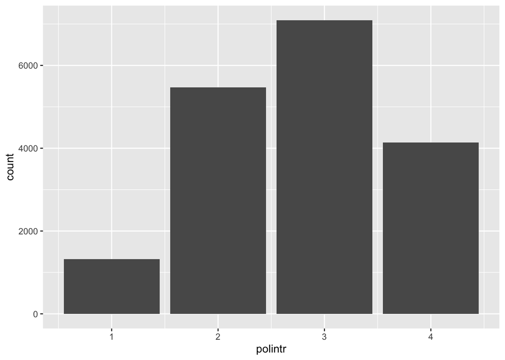

```r
df %>%
  ggplot(aes(x = polintr)) +
  geom_bar()
```

```r
# Cambiar las variables a gusto para ir viendo cómo se van distribuyendo y sus particularidades
```

```r
df$polintr<- factor(df$polintr, #objeto
                                  levels = c(1,2,3,4),  #valores o niveles numéricos
                                  labels = c("Muy interesado", "Interesado", "Poco interesado", "Nada interesado"),
                    exclude = NA) #significados de cada valor numérico
```

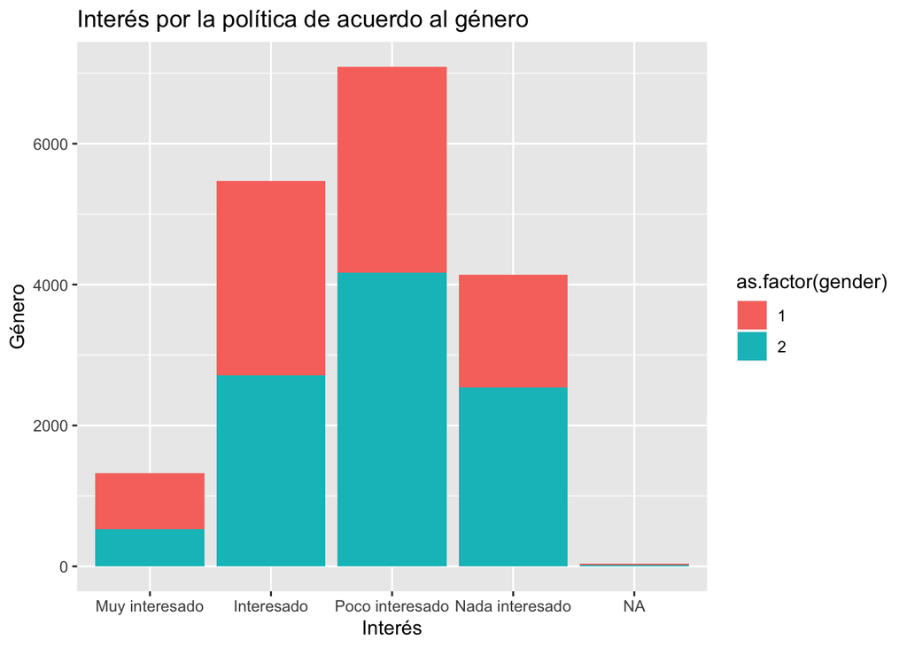

```r
df %>% #selección de data frame
  ggplot(aes(polintr, fill = as.factor(gender))) + #definir el tamaño del lienzo
  geom_bar() + #definir el tipo de gráfica de los datos
  labs(title = "Interés por la política de acuerdo al género", #texto de la gráfica
       x = "Interés",
       y = "Género")
```

Qué ha ocurrido? Se nos ha olvidado convertir en factor la variable género también, de ahí que salga el valor numérico asignado

```r
df$gender<- factor(df$gender, #objeto
                                  levels = c(1,2),  #valores o niveles numéricos
                                  labels = c("hombre", "mujer")
                   ) #significados de cada valor numérico
```

Ahora repetimos el gráfico a ver qué tal:

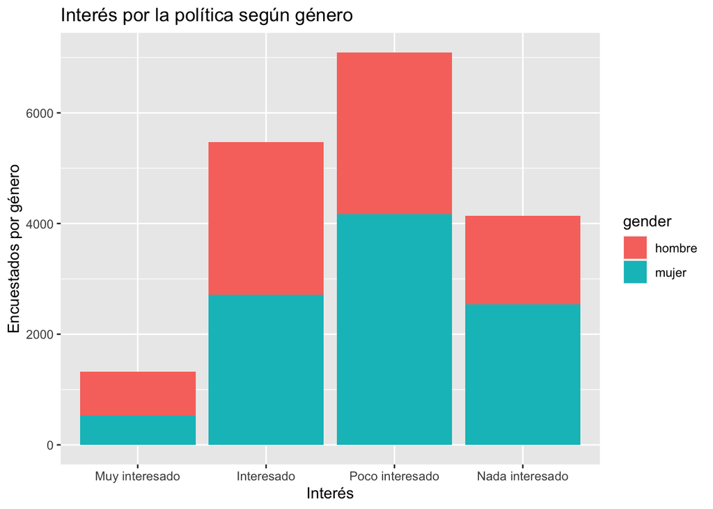

```r
df %>% #selección de data frame
  drop_na(polintr, gender) %>% #remover los casos "perdidos"
  ggplot(aes(polintr, fill = gender)) + #definir el tamaño del lienzo
  geom_bar() + #definir el tipo de gráfica de los datos
  labs(title = "Interés por la política según género", #texto de la gráfica
       x = "Interés",
       y = "Encuestados por género")
```

## Tablas de contingencia y pruebas de independencia

```r
tabla_abs<-table(df$polintr, df$gender) #formato de variables (y - renglón, x - columna)
tabla_abs
```

```
##
##                   hombre mujer
##   Muy interesado     792   527
##   Interesado        2759  2710
##   Poco interesado   2927  4166
##   Nada interesado   1601  2536
```

Tabla de contingencia con proporciones totales:

```r
round(prop.table(tabla_abs), 2) #proporciones totales reducidas a 2 decimales
```

```
##
##                   hombre mujer
##   Muy interesado    0.04  0.03
##   Interesado        0.15  0.15
##   Poco interesado   0.16  0.23
##   Nada interesado   0.09  0.14
```

Tabla de contingencia con proporciones condicionales por fila:

```r
round(prop.table(tabla_abs, 1), 2) #proporciones por fila reducida a 2 decimales
```

```
##
##                   hombre mujer
##   Muy interesado    0.60  0.40
##   Interesado        0.50  0.50
##   Poco interesado   0.41  0.59
##   Nada interesado   0.39  0.61
```

Tabla de contingencia con proporciones condicionales por columna:

```r
round(prop.table(tabla_abs, 2), 2) #proporciones por columna reducida a 2 decimales
```

```
##
##                   hombre mujer
##   Muy interesado    0.10  0.05
##   Interesado        0.34  0.27
##   Poco interesado   0.36  0.42
##   Nada interesado   0.20  0.26
```

```r
#Tabla de contingencia con sumas absolutas en los marginales:
addmargins(tabla_abs, c(1, 2))
```

```
##
##                   hombre mujer   Sum
##   Muy interesado     792   527  1319
##   Interesado        2759  2710  5469
##   Poco interesado   2927  4166  7093
##   Nada interesado   1601  2536  4137
##   Sum               8079  9939 18018
```

Tabla de contingencia con sumas de proporciones en los marginales:

```r
round(addmargins(prop.table(tabla_abs), c(1, 2)), 2)
```

```
##
##                   hombre mujer  Sum
##   Muy interesado    0.04  0.03 0.07
##   Interesado        0.15  0.15 0.30
##   Poco interesado   0.16  0.23 0.39
##   Nada interesado   0.09  0.14 0.23
##   Sum               0.45  0.55 1.00
```

### Tablas de frecuencias y de contingencia con librería `descr`

La librería `descr` contiene algunas funciones o códigos que también permiten generar tablas de frecuencias así como tablas de contingencia. La diferencia respecto de los scripts del sistema base radican en el formato de salida que arroja y en la posibilidad de generar gráficos de barras acumuladas, de manera automática.

En el caso de las tablas de frecuencias, el script para solicitarlas para una variable es `freq()`, y tiene la siguiente estructura: `freq(x, w, user.missing = , plot = , …)`, donde:

`x =` la variable factor de la que se desea conocer sus frecuencias, `w =` un vector adicional para ponderar la tabla de frecuencias, `user.missing =` vector de caracteres que indica cuáles son los niveles que deben se tratados como valores perdidos al calcular los porcentajes válidos, y estos no son representados en la gráfica de barras acumuladas. `plot =` valor lógico (TRUE es el valor por default) que indica si se debe generar el gráfico de frecuencias `… =` argumentos adicionales que se adjuntan a la gráfica de frecuencias en caso de que `plot = TRUE`.

En el caso del ejemplo realizado hasta el momento basado en la variable `gender`, se pueden solicitar las distribuciones de frecuencias absolutas y relativas (porcentajes) para cada una de la siguiente manera:

```r
#install.packages("descr")
#library(descr)
descr::freq(df$gender, plot = FALSE)
```

```
## df$gender
##        Frequency Percent
## hombre      8100   44.85
## mujer       9960   55.15
## Total      18060  100.00
```

En caso de necesitar la versión gráfica para la representación de estos datos, se activa la opción de gráfica:

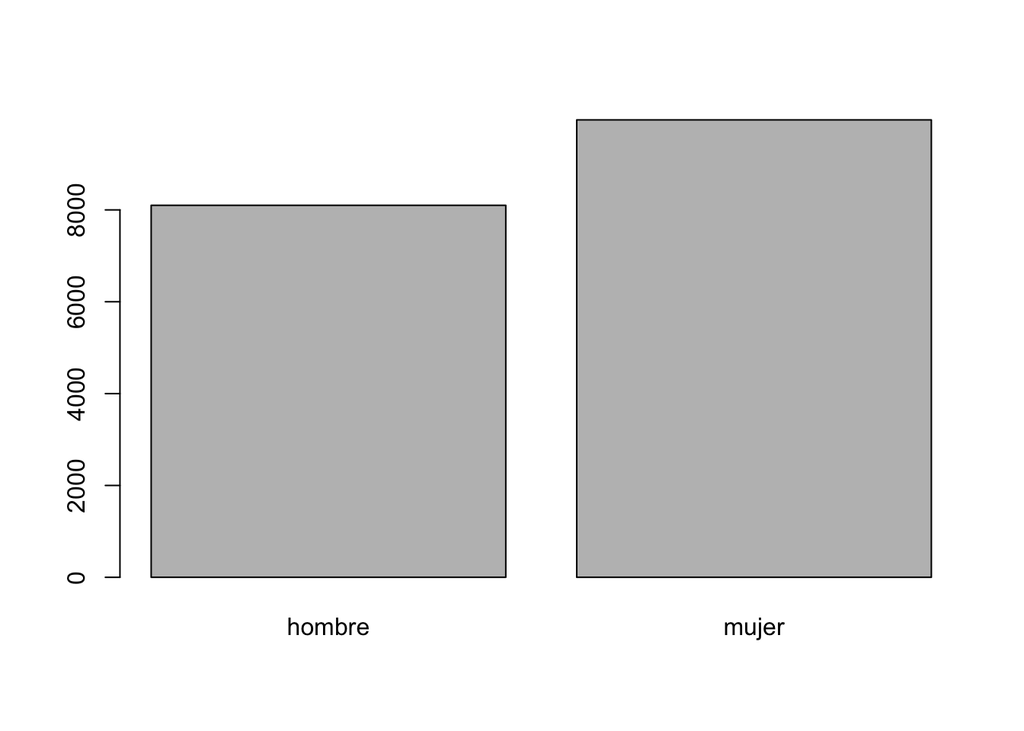

```
## df$gender
##        Frequency Percent
## hombre      8100   44.85
## mujer       9960   55.15
## Total      18060  100.00
```

```r
descr::freq(df$gender, plot = TRUE)
```

Por otra parte, se puede solicitar una tabla de contingencia (o tabla cruzada) para conocer la asociación existente entre dos variables a partir de la función `crosstab()`.

```r
#descr::crosstab(df$gender, df$polintr,
 #        expected = TRUE,
  #       prop.c = TRUE,
   #      prop.t = TRUE,
    #     resid = TRUE,
     #    format = "SPSS",
      #   percent = TRUE,
       #  main = "Asociación entre interés por la política y género",
        # xlab = "Interés por la política",
        #ylab = "Género",
        # plot = TRUE)
```

```r
#chisq.test(tabla_abs)
```

```r
#descr::crosstab(df$gender, df$polintr,
 #        expected = TRUE,
  #       prop.c = TRUE,
   #      prop.t = TRUE,
    #     resid = TRUE,
    #     chisq = TRUE,
    #     format = "SPSS",
    #     percent = TRUE,
    #     main = "Asociación entre interés por la política y género",
    #     xlab = "Interés por la política",
    #     ylab = "Género",
    #     plot = TRUE)
```